# CovBat Simulations: Additional Parameters

Andrew Chen

## Simulation design

Let $\boldsymbol{y}_{ij}$, $i = 1, 2, \ldots, M$, $j = 1, 2, \ldots, n_i$ be vectors representing simulated cortical thickness values in 62 regions. The $\boldsymbol{y}_{ij}$ are generated using the following model:
$$\begin{equation*}
\boldsymbol{y}_{ij} = \boldsymbol{\alpha} + x_{ij} \boldsymbol{\beta} + \boldsymbol{\gamma}_i + \boldsymbol{\delta}_i^T \boldsymbol{e}_{ij}
\end{equation*}$$
where $\boldsymbol{\alpha}$ is the sample mean vector of Scanner B observations in the ADNI data, $\boldsymbol{\beta}$ is the vector of predictor effects on the mean, and $x_{ij}$ is a binary covariate drawn from a $\text{Bernoulli}\,(0.25)$ distribution. The mean scanner effects $\boldsymbol{\gamma}_i = (\gamma_{i1}, \gamma_{i2}, \ldots, \gamma_{i62})'$ are vectors drawn from independent and identically distributed (i.i.d.) normal distributions with mean zero and the variance scanner effects $\boldsymbol{\delta}_i = (\delta_{i1}, \delta_{i2}, \ldots, \delta_{i62})'$ are vectors drawn from site-specific inverse gamma distributions with chosen parameters. The error terms are generated via
$$\boldsymbol{e}_{ij} \sim N(\boldsymbol{0}, S(\Sigma + c_i\Omega_i + x_{ij}\Psi)S)$$
where $\Sigma$ is the sample covariance matrix of Scanner B observations in the ADNI data, $\Omega_i$ are site-specific covariance shift matrices, $\Psi$ is a chosen covariance shift matrix which can be similar to any of the $\Omega_i$, and $S = \textbf{diag(s)}$ where $s_k = (\Sigma + \Omega_i + x_{ij}\Psi)_{kk}^{-1/2}$ to constrain the variances to equal 1. The $S$ terms were introduced to ensure that detection of covariance site effects is not driven by variance effects. To ensure that the covariance matrices are positive semi-definite, we set the negative eigenvalues of $\Sigma + \Omega_i + x_{ij}\Psi$ equal to a small constant, $10^{-12}$.

## Simulation Parameters

To further investigate our initial simulation results, we obtain results over a series of parameter values. Each displayed matrix is organized such that the columns represent (in order) low, medium, high, and no effect:

- Mean site effect $\gamma_{ij} \sim N(0, \sigma_G)$, $\sigma_G = (0.001, 0.05, 0.25)$
- Variance site effect $\delta_{ij} \sim \text{Inverse Gamma}\,(a_i,b_i)$. With site on the rows, the parameters are
  $$a = \begin{bmatrix}46&21&8 \\51&26&11 \\56&31&14 \\\end{bmatrix} \hspace{50mm} b =\begin{bmatrix}50&25&10 \\50&25&10 \\50&25&10 \\\end{bmatrix}$$
- Covariance site effect $c_i$ in $c_i\Omega_i$ with
  $$c = \begin{bmatrix}-0.25&-0.5&-1&0 \\0.5&1&2&0 \\1&2&4&0 \\\end{bmatrix}$$

[figure not shown]

- Covariate mean effect $\boldsymbol{\beta} = (\beta_1,\ldots,\beta_{62})$ where $\beta_1=\cdots=\beta_{15} = \beta_{32}=\cdots=\beta_{46}=d$ and $d = (-0.1, -0.25, -0.5, 0)$.
- Covariate effect on covariance $\Psi = v_1\Omega_1 + v_2\Omega_2 + v_3\Omega_3$ where $v = \begin{bmatrix}0&0&0&0 \\0&0&0&0 \\-2&-3&-4&0 \\\end{bmatrix}$

## Insights from unreported tests

- In largest ADNI sites, $\gamma_{ij}$ had mean 0.02 and SD 0.32
  - $\delta_{ij}$ had mean 1.03 and SD 0.16
- For smaller sample sizes (~100 observations per site)
  - Estimates of $\boldsymbol{\beta}$ are often biased, which can lead to removal of covariate effects
  - Mean/variance site effects can arise from variability in multivariate normal draws
- Relatively small variance site effects (scaling by ~1.25 in one site) can lead to near-perfect detection
  - Variance of inverse gamma distributions needed to be scaled down substantially
- Correlation site effects (modification of only off-diagonal) lead to more modest changes in AUC
- Careful tuning required to ensure that performance is not overly driven by mean/variance site effects instead of correlation site effects
  - To accomplish this, simulation needed to be modified to separate out variance and correlation site effects
- Even in cases of severe covariance effect on variance, ComBat does not show major covariance detection improvements
  - Likely because variance harmonized across site without regard for covariate effects

## ComBat-like Simulations

We follow the ComBat model so that there are site effects in mean and variance, but not covariance. The covariate only has effect on the mean. We vary our simulations over site effects (both mean and variance) and covariate effects (just mean) ranging across low, medium, and high.

### Results for site detection

| Site Effect | Covariate Effect | Unharmonized | ComBat-Adjusted | CovBat-Adjusted |
| --- | --- | --- | --- | --- |
| Low | Low | 0.65 (0.03) | 0.52 (0.02) | 0.53 (0.03) |
| Low | Med | 0.64 (0.03) | 0.53 (0.02) | 0.53 (0.03) |
| Low | High | 0.65 (0.04) | 0.52 (0.02) | 0.53 (0.03) |
| Med | Low | 0.95 (0.02) | 0.53 (0.03) | 0.53 (0.03) |
| Med | Med | 0.96 (0.02) | 0.53 (0.03) | 0.53 (0.03) |
| Med | High | 0.96 (0.02) | 0.53 (0.03) | 0.53 (0.03) |
| High | Low | 1 (0) | 0.54 (0.03) | 0.54 (0.03) |
| High | Med | 1 (0) | 0.54 (0.03) | 0.54 (0.03) |
| High | High | 1 (0) | 0.54 (0.03) | 0.54 (0.03) |

### Results for covariate detection

| Site Effect | Covariate Effect | Unharmonized | ComBat-Adjusted | CovBat-Adjusted |
| --- | --- | --- | --- | --- |
| Low | Low | 0.54 (0.03) | 0.54 (0.03) | 0.54 (0.03) |
| Low | Med | 0.66 (0.03) | 0.66 (0.04) | 0.66 (0.04) |
| Low | High | 0.87 (0.03) | 0.86 (0.03) | 0.87 (0.03) |
| Med | Low | 0.53 (0.03) | 0.53 (0.03) | 0.54 (0.03) |
| Med | Med | 0.66 (0.04) | 0.66 (0.04) | 0.66 (0.04) |
| Med | High | 0.86 (0.03) | 0.86 (0.03) | 0.86 (0.03) |
| High | Low | 0.53 (0.03) | 0.54 (0.03) | 0.54 (0.03) |
| High | Med | 0.65 (0.04) | 0.66 (0.04) | 0.66 (0.04) |
| High | High | 0.85 (0.03) | 0.86 (0.03) | 0.87 (0.03) |

### Medium site effect, high covariate effect

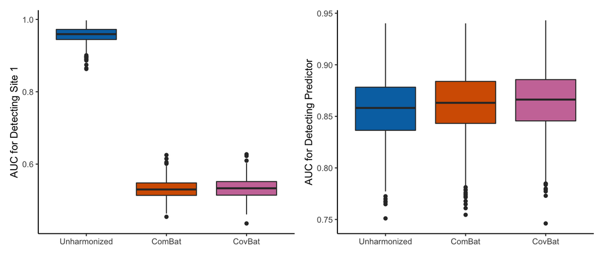

## No Confounding Simulations

We implement a No Confounding simulation which has site effects in mean and covariance. The covariate only has effect on the mean. We vary our simulations over site effects (both mean and variance), covariate effects (just mean), and covariance site effects ranging across low, medium, and high.

### Results for site detection

| Site Effect | Covariate Effect | Covariance Site Effect | Unharmonized | ComBat-Adjusted | CovBat-Adjusted |
| --- | --- | --- | --- | --- | --- |
| Low | Low | Low | 0.71 (0.03) | 0.56 (0.04) | 0.53 (0.03) |
| Low | Low | Med | 0.78 (0.03) | 0.67 (0.04) | 0.62 (0.03) |
| Low | Low | High | 0.88 (0.02) | 0.83 (0.03) | 0.74 (0.04) |
| Low | Med | Low | 0.71 (0.03) | 0.56 (0.04) | 0.53 (0.03) |
| Low | Med | Med | 0.78 (0.03) | 0.67 (0.04) | 0.62 (0.03) |
| Low | Med | High | 0.88 (0.03) | 0.83 (0.03) | 0.74 (0.04) |
| Low | High | Low | 0.71 (0.03) | 0.56 (0.03) | 0.53 (0.03) |
| Low | High | Med | 0.78 (0.03) | 0.67 (0.04) | 0.62 (0.03) |
| Low | High | High | 0.88 (0.02) | 0.83 (0.03) | 0.74 (0.04) |
| Med | Low | Low | 0.96 (0.02) | 0.55 (0.04) | 0.53 (0.03) |
| Med | Low | Med | 0.97 (0.02) | 0.67 (0.04) | 0.62 (0.04) |
| Med | Low | High | 0.98 (0.01) | 0.83 (0.03) | 0.74 (0.04) |
| Med | Med | Low | 0.96 (0.02) | 0.55 (0.03) | 0.53 (0.03) |
| Med | Med | Med | 0.97 (0.02) | 0.66 (0.04) | 0.62 (0.03) |
| Med | Med | High | 0.98 (0.01) | 0.83 (0.03) | 0.74 (0.03) |
| Med | High | Low | 0.96 (0.02) | 0.55 (0.04) | 0.53 (0.03) |
| Med | High | Med | 0.97 (0.02) | 0.66 (0.04) | 0.62 (0.03) |
| Med | High | High | 0.98 (0.01) | 0.83 (0.03) | 0.74 (0.04) |
| High | Low | Low | 1 (0) | 0.54 (0.03) | 0.52 (0.03) |
| High | Low | Med | 1 (0) | 0.66 (0.04) | 0.61 (0.04) |
| High | Low | High | 1 (0) | 0.82 (0.03) | 0.74 (0.04) |
| High | Med | Low | 1 (0) | 0.54 (0.03) | 0.53 (0.03) |
| High | Med | Med | 1 (0) | 0.65 (0.04) | 0.61 (0.03) |
| High | Med | High | 1 (0) | 0.82 (0.03) | 0.74 (0.04) |
| High | High | Low | 1 (0) | 0.54 (0.03) | 0.52 (0.02) |
| High | High | Med | 1 (0) | 0.66 (0.04) | 0.61 (0.03) |
| High | High | High | 1 (0) | 0.82 (0.03) | 0.74 (0.04) |

### Results for covariate detection

| Site Effect | Covariate Effect | Covariance Site Effect | Unharmonized | ComBat-Adjusted | CovBat-Adjusted |
| --- | --- | --- | --- | --- | --- |
| Low | Low | Low | 0.54 (0.03) | 0.54 (0.03) | 0.54 (0.03) |
| Low | Low | Med | 0.54 (0.03) | 0.53 (0.03) | 0.54 (0.03) |
| Low | Low | High | 0.53 (0.03) | 0.53 (0.03) | 0.53 (0.03) |
| Low | Med | Low | 0.66 (0.04) | 0.65 (0.04) | 0.66 (0.04) |
| Low | Med | Med | 0.65 (0.04) | 0.65 (0.04) | 0.65 (0.04) |
| Low | Med | High | 0.64 (0.04) | 0.64 (0.04) | 0.64 (0.04) |
| Low | High | Low | 0.85 (0.03) | 0.85 (0.03) | 0.85 (0.03) |
| Low | High | Med | 0.84 (0.03) | 0.84 (0.03) | 0.84 (0.03) |
| Low | High | High | 0.82 (0.03) | 0.82 (0.03) | 0.82 (0.03) |
| Med | Low | Low | 0.53 (0.03) | 0.54 (0.03) | 0.54 (0.03) |
| Med | Low | Med | 0.53 (0.03) | 0.53 (0.03) | 0.54 (0.03) |
| Med | Low | High | 0.53 (0.03) | 0.53 (0.03) | 0.53 (0.03) |
| Med | Med | Low | 0.65 (0.04) | 0.65 (0.03) | 0.65 (0.04) |
| Med | Med | Med | 0.64 (0.04) | 0.65 (0.04) | 0.64 (0.04) |
| Med | Med | High | 0.63 (0.04) | 0.64 (0.04) | 0.64 (0.03) |
| Med | High | Low | 0.84 (0.03) | 0.85 (0.03) | 0.85 (0.03) |
| Med | High | Med | 0.83 (0.03) | 0.84 (0.03) | 0.84 (0.03) |
| Med | High | High | 0.82 (0.03) | 0.82 (0.03) | 0.82 (0.03) |
| High | Low | Low | 0.53 (0.03) | 0.53 (0.03) | 0.54 (0.03) |
| High | Low | Med | 0.53 (0.03) | 0.53 (0.03) | 0.53 (0.03) |
| High | Low | High | 0.53 (0.03) | 0.53 (0.03) | 0.53 (0.03) |
| High | Med | Low | 0.64 (0.04) | 0.65 (0.04) | 0.65 (0.04) |
| High | Med | Med | 0.64 (0.04) | 0.64 (0.04) | 0.64 (0.03) |
| High | Med | High | 0.63 (0.04) | 0.64 (0.04) | 0.64 (0.04) |
| High | High | Low | 0.83 (0.03) | 0.85 (0.03) | 0.85 (0.03) |
| High | High | Med | 0.83 (0.03) | 0.84 (0.03) | 0.84 (0.03) |
| High | High | High | 0.82 (0.03) | 0.82 (0.03) | 0.82 (0.03) |

### Medium site effect, medium covariate effect, high covariance effect

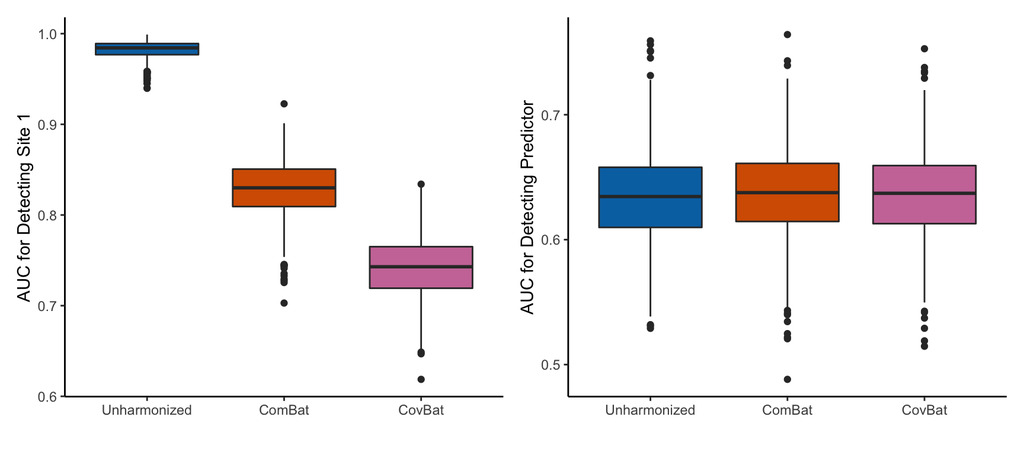

## Confounding Simulations

We implement a Confounding simulation which has site effects in mean and covariance. The covariate has effect on both mean and covariance, where the latter effect is confounded with the effect of Site 3. We vary our simulations over site effects (both mean and variance), covariate effects (mean and covariance), and covariance site effects ranging across low, medium, and high.

### Results for site detection

| Site Effect | Covariate Effect | Covariance Site Effect | Unharmonized | ComBat-Adjusted | CovBat-Adjusted |
| --- | --- | --- | --- | --- | --- |
| Low | Low | Low | 0.71 (0.03) | 0.55 (0.03) | 0.52 (0.02) |
| Low | Low | Med | 0.79 (0.03) | 0.67 (0.04) | 0.6 (0.03) |
| Low | Low | High | 0.89 (0.02) | 0.84 (0.03) | 0.74 (0.04) |
| Low | Med | Low | 0.69 (0.03) | 0.54 (0.03) | 0.52 (0.02) |
| Low | Med | Med | 0.77 (0.03) | 0.64 (0.04) | 0.57 (0.03) |
| Low | Med | High | 0.88 (0.02) | 0.82 (0.03) | 0.72 (0.03) |
| Low | High | Low | 0.69 (0.03) | 0.53 (0.03) | 0.52 (0.02) |
| Low | High | Med | 0.75 (0.03) | 0.62 (0.04) | 0.56 (0.03) |
| Low | High | High | 0.87 (0.02) | 0.8 (0.03) | 0.7 (0.03) |
| Med | Low | Low | 0.95 (0.02) | 0.54 (0.03) | 0.52 (0.02) |
| Med | Low | Med | 0.97 (0.02) | 0.66 (0.04) | 0.6 (0.03) |
| Med | Low | High | 0.98 (0.01) | 0.83 (0.03) | 0.74 (0.03) |
| Med | Med | Low | 0.95 (0.02) | 0.53 (0.03) | 0.52 (0.02) |
| Med | Med | Med | 0.96 (0.02) | 0.63 (0.04) | 0.57 (0.04) |
| Med | Med | High | 0.98 (0.01) | 0.82 (0.03) | 0.72 (0.04) |
| Med | High | Low | 0.95 (0.02) | 0.53 (0.03) | 0.52 (0.02) |
| Med | High | Med | 0.96 (0.02) | 0.61 (0.04) | 0.56 (0.03) |
| Med | High | High | 0.98 (0.01) | 0.8 (0.03) | 0.7 (0.03) |
| High | Low | Low | 1 (0) | 0.53 (0.03) | 0.52 (0.02) |
| High | Low | Med | 1 (0) | 0.66 (0.04) | 0.6 (0.03) |
| High | Low | High | 1 (0) | 0.83 (0.03) | 0.73 (0.03) |
| High | Med | Low | 1 (0) | 0.53 (0.03) | 0.52 (0.02) |
| High | Med | Med | 1 (0) | 0.62 (0.04) | 0.57 (0.03) |
| High | Med | High | 1 (0) | 0.81 (0.03) | 0.71 (0.03) |
| High | High | Low | 1 (0) | 0.52 (0.02) | 0.52 (0.02) |
| High | High | Med | 1 (0) | 0.6 (0.04) | 0.55 (0.03) |
| High | High | High | 1 (0) | 0.79 (0.03) | 0.69 (0.03) |

### Results for covariate detection

| Site Effect | Covariate Effect | Covariance Site Effect | Unharmonized | ComBat-Adjusted | CovBat-Adjusted |
| --- | --- | --- | --- | --- | --- |
| Low | Low | Low | 0.74 (0.04) | 0.75 (0.04) | 0.75 (0.03) |
| Low | Low | Med | 0.65 (0.04) | 0.65 (0.04) | 0.66 (0.04) |
| Low | Low | High | 0.59 (0.04) | 0.59 (0.04) | 0.6 (0.04) |
| Low | Med | Low | 0.89 (0.03) | 0.89 (0.03) | 0.89 (0.02) |
| Low | Med | Med | 0.82 (0.03) | 0.83 (0.03) | 0.84 (0.03) |
| Low | Med | High | 0.72 (0.03) | 0.72 (0.03) | 0.74 (0.03) |
| Low | High | Low | 0.97 (0.01) | 0.97 (0.01) | 0.97 (0.01) |
| Low | High | Med | 0.95 (0.02) | 0.95 (0.02) | 0.95 (0.01) |
| Low | High | High | 0.88 (0.03) | 0.88 (0.03) | 0.9 (0.02) |
| Med | Low | Low | 0.73 (0.04) | 0.75 (0.04) | 0.75 (0.03) |
| Med | Low | Med | 0.64 (0.04) | 0.65 (0.04) | 0.66 (0.04) |
| Med | Low | High | 0.59 (0.04) | 0.59 (0.04) | 0.6 (0.04) |
| Med | Med | Low | 0.87 (0.03) | 0.89 (0.03) | 0.89 (0.03) |
| Med | Med | Med | 0.81 (0.03) | 0.83 (0.03) | 0.84 (0.03) |
| Med | Med | High | 0.71 (0.04) | 0.72 (0.04) | 0.74 (0.03) |
| Med | High | Low | 0.96 (0.01) | 0.97 (0.01) | 0.97 (0.01) |
| Med | High | Med | 0.94 (0.02) | 0.95 (0.02) | 0.95 (0.02) |
| Med | High | High | 0.88 (0.03) | 0.88 (0.02) | 0.89 (0.02) |
| High | Low | Low | 0.7 (0.04) | 0.75 (0.03) | 0.75 (0.03) |
| High | Low | Med | 0.64 (0.04) | 0.65 (0.04) | 0.66 (0.04) |
| High | Low | High | 0.59 (0.04) | 0.59 (0.04) | 0.6 (0.04) |
| High | Med | Low | 0.85 (0.03) | 0.89 (0.03) | 0.89 (0.03) |
| High | Med | Med | 0.8 (0.03) | 0.83 (0.03) | 0.84 (0.03) |
| High | Med | High | 0.72 (0.03) | 0.72 (0.03) | 0.74 (0.03) |
| High | High | Low | 0.95 (0.02) | 0.97 (0.01) | 0.97 (0.01) |
| High | High | Med | 0.93 (0.02) | 0.95 (0.02) | 0.95 (0.02) |
| High | High | High | 0.88 (0.03) | 0.88 (0.02) | 0.9 (0.02) |

### Medium site effect, medium covariate effect, high covariance effect

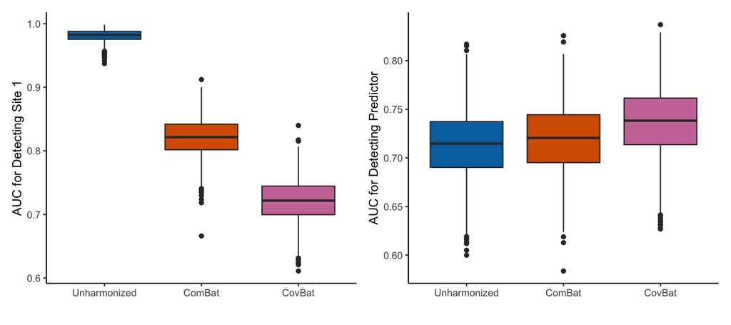

## Only Covariance Simulations

This simulation is used to isolate the effects of covariance on the MVPA experiement. Here, the site effect only exists in covariance. The covariate has effect on only covariance such that it is still confounded with the covariance effect of Site 3. We vary our simulations over covariate effects (covariance only) and covariance site effects ranging across low, medium, and high.

### Results for site detection

| Covariate Effect | Covariance Site Effect | Unharmonized | ComBat-Adjusted | CovBat-Adjusted |
| --- | --- | --- | --- | --- |
| Low | Low | 0.57 (0.03) | 0.54 (0.03) | 0.52 (0.02) |
| Low | Med | 0.69 (0.03) | 0.66 (0.04) | 0.59 (0.03) |
| Low | High | 0.84 (0.03) | 0.83 (0.03) | 0.73 (0.03) |
| Med | Low | 0.56 (0.03) | 0.53 (0.03) | 0.52 (0.02) |
| Med | Med | 0.66 (0.03) | 0.63 (0.04) | 0.57 (0.03) |
| Med | High | 0.83 (0.03) | 0.82 (0.03) | 0.72 (0.04) |
| High | Low | 0.55 (0.03) | 0.53 (0.03) | 0.52 (0.02) |
| High | Med | 0.64 (0.03) | 0.61 (0.04) | 0.55 (0.03) |
| High | High | 0.81 (0.03) | 0.8 (0.03) | 0.69 (0.03) |

### Results for covariate detection

| Covariate Effect | Covariance Site Effect | Unharmonized | ComBat-Adjusted | CovBat-Adjusted |
| --- | --- | --- | --- | --- |
| Low | Low | 0.73 (0.04) | 0.73 (0.04) | 0.74 (0.03) |
| Low | Med | 0.63 (0.04) | 0.63 (0.04) | 0.64 (0.04) |
| Low | High | 0.57 (0.04) | 0.57 (0.04) | 0.58 (0.04) |
| Med | Low | 0.84 (0.03) | 0.84 (0.03) | 0.85 (0.03) |
| Med | Med | 0.76 (0.03) | 0.76 (0.03) | 0.78 (0.03) |
| Med | High | 0.62 (0.04) | 0.62 (0.04) | 0.64 (0.04) |
| High | Low | 0.9 (0.03) | 0.9 (0.03) | 0.91 (0.03) |
| High | Med | 0.85 (0.03) | 0.85 (0.03) | 0.87 (0.03) |
| High | High | 0.68 (0.04) | 0.68 (0.04) | 0.71 (0.04) |

### High covariate effect, high covariance effect

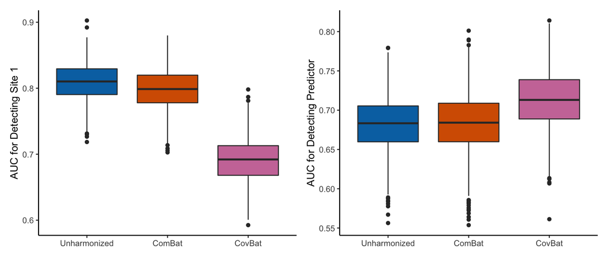